# Far out! Demonstrating, Exploring and Analyzing Current Asteroid Patterns and Properties Through Utilization of Statistical data.

## Introduction

Asteroids. The abundance of leftover rocks from the formation of our solar system approximately 4.6 billion years ago has been discovered and studied by astronomers for centuries. Using a dataset obtained by NASA's Jet Propulsion Labratory, we will explore a subset (approx 10,000) of asteroids found so far, observing possible patterns in our discovery timeline, and statistically demonstrating certain properties of the asteroids in our solar system.

### Some Background Information on Asteroids.

The definition of an asteroid is a small, rocky or metallic body astrological body that orbits around the Sun. Most asteroids discovered are found in our Asteroid Belt. The amount of time it takes for an asteroid to orbit around the Sun is called the period, measured in our dataset as years. and the distance or mean distance from the asteroid to the Sun is called the semi-major axis, measured in our dataset as Astronomical Units, which is the distance from Earth to the Sun as a unit. The eccentricity of asteroid is how eccentric the asteroid's orbit is. It is measured from 0 to 1, with a measurement closer to 0 being more circular and closer to 1 being more like an ovular shape. These properties of asteroids are what we will be focusing on in this dataset.

These will be the packages used in the project. Pandas for curation and manipulation of the dataframes, Numpy for possible use of arrays for our dataframes, matplotlib for data visualization and sklearn for linear regression of data.

```python
import pandas as pd
import numpy as np
import matplotlib.pyplot as plt
from sklearn import linear_model
```

## Data Collection

To obtain my data, I rely on Nasa's Jet Propulsion Labratory Database Search Engine. It contains information and records on discovered small space objects. I filter out the table so that it only shows all discovered asteroids and the main properties (period, semi-major axis, etc.) and upload that table onto the notebook.

```python
asteroidData = pd.read_csv("updatedasteroiddata.csv") #Reads off the csv file of asteroid data into a Pandas dataframe
asteroidData.head() #Shows first couple of rows of the table
```

|  | full_name | pdes | orbit_id | e | a | diameter | per_y | q | class | first_obs | last_obs | name |
| --- | --- | --- | --- | --- | --- | --- | --- | --- | --- | --- | --- | --- |
| 0 | 1 Ceres (A801 AA) | 1 | JPL 48 | 0.078168 | 2.766089 | 939.400 | 4.600526 | 2.549868 | MBA | 1995-01-05 | 2021-01-28 | Ceres |
| 1 | 2 Pallas (A802 FA) | 2 | JPL 42 | 0.229750 | 2.774382 | 545.000 | 4.621229 | 2.136967 | MBA | 1804-08-27 | 2020-11-05 | Pallas |
| 2 | 3 Juno (A804 RA) | 3 | JPL 117 | 0.256988 | 2.668020 | 246.596 | 4.358046 | 1.982370 | MBA | 1804-10-17 | 2021-03-13 | Juno |
| 3 | 4 Vesta (A807 FA) | 4 | JPL 36 | 0.088425 | 2.362030 | 525.400 | 3.630248 | 2.153168 | MBA | 1950-09-23 | 2021-03-17 | Vesta |
| 4 | 5 Astraea (A845 XA) | 5 | JPL 119 | 0.190788 | 2.573621 | 106.699 | 4.128811 | 2.082605 | MBA | 1845-12-15 | 2021-03-23 | Astraea |

There we go!

## Cleaning Up our Data

Now that we have acquired our asteroid data, lets go ahead and clean it up some. We'll go ahead and delete unwanted columns. Primary designation we won't need here as well as the orbit ID. Since we already have the semi-major axis, we won't need the perihelion (q). We won't really be looking at the observation times of the asteroids so we can drop last_obs, but just in case we will keep the dates of the first observation. Class would also not be needed in this project. Since we already have a full-name column, the name column won't be needed as well.

```python
asteroidData = asteroidData.drop(['pdes','orbit_id', 'q','class','last_obs','name'], axis = 1) #Dropping columns

asteroidData.head()
```

|  | full_name | e | a | diameter | per_y | first_obs |
| --- | --- | --- | --- | --- | --- | --- |
| 0 | 1 Ceres (A801 AA) | 0.078168 | 2.766089 | 939.400 | 4.600526 | 1995-01-05 |
| 1 | 2 Pallas (A802 FA) | 0.229750 | 2.774382 | 545.000 | 4.621229 | 1804-08-27 |
| 2 | 3 Juno (A804 RA) | 0.256988 | 2.668020 | 246.596 | 4.358046 | 1804-10-17 |
| 3 | 4 Vesta (A807 FA) | 0.088425 | 2.362030 | 525.400 | 3.630248 | 1950-09-23 |
| 4 | 5 Astraea (A845 XA) | 0.190788 | 2.573621 | 106.699 | 4.128811 | 1845-12-15 |

Now, because of the processing power and memory of my current laptop, It is very likely that my computer will crash trying to visualize over one million points of data. What we will do here to cut our rows is pick every 100th row of data, so that we will have only approximately 10,000 asteroids spanning 2 centuries of discovery.

```python
cutasteroiddata = asteroidData[asteroidData.index % 100 == 0]
cutasteroiddata = cutasteroiddata.reset_index() #resetting our index, as we wouldn't want our index to be "1, 100, 200..."
cutasteroiddata = cutasteroiddata.drop('index', axis = 1) #dropping our old index
cutasteroiddata
```

|  | full_name | e | a | diameter | per_y | first_obs |
| --- | --- | --- | --- | --- | --- | --- |
| 0 | 1 Ceres (A801 AA) | 0.078168 | 2.766089 | 939.400 | 4.600526 | 1995-01-05 |
| 1 | 101 Helena (A868 PA) | 0.140748 | 2.582631 | 65.840 | 4.150513 | 1871-03-22 |
| 2 | 201 Penelope (A879 PA) | 0.179296 | 2.678770 | 85.877 | 4.384411 | 1879-08-13 |
| 3 | 301 Bavaria (A890 WA) | 0.066974 | 2.723923 | 53.042 | 4.495733 | 1891-01-11 |
| 4 | 401 Ottilia (A895 FA) | 0.031819 | 3.343575 | 87.803 | 6.113992 | 1895-03-19 |
| ... | ... | ... | ... | ... | ... | ... |
| 10814 | (2021 GW69) | 0.042086 | 2.889559 | NaN | 4.911967 | 2021-04-15 |
| 10815 | (2021 HG1) | 0.298977 | 0.929201 | NaN | 0.895721 | 2021-04-17 |
| 10816 | (2021 HK5) | 0.140148 | 2.586386 | NaN | 4.159568 | 2021-04-17 |
| 10817 | (2021 JP3) | 0.493551 | 2.035589 | NaN | 2.904313 | 2021-05-08 |
| 10818 | (2021 JP7) | 0.070037 | 1.864554 | NaN | 2.546072 | 2021-05-11 |

10819 rows × 6 columns

Now, lets rename these columns to make it easier to read.

```python
cutasteroiddata = cutasteroiddata.rename(columns={"e": "eccentricity", "a": "smi-mjr_axis", "per_y": "period_years"})
cutasteroiddata.head()
```

|  | full_name | eccentricity | smi-mjr_axis | diameter | period_years | first_obs |
| --- | --- | --- | --- | --- | --- | --- |
| 0 | 1 Ceres (A801 AA) | 0.078168 | 2.766089 | 939.400 | 4.600526 | 1995-01-05 |
| 1 | 101 Helena (A868 PA) | 0.140748 | 2.582631 | 65.840 | 4.150513 | 1871-03-22 |
| 2 | 201 Penelope (A879 PA) | 0.179296 | 2.678770 | 85.877 | 4.384411 | 1879-08-13 |
| 3 | 301 Bavaria (A890 WA) | 0.066974 | 2.723923 | 53.042 | 4.495733 | 1891-01-11 |
| 4 | 401 Ottilia (A895 FA) | 0.031819 | 3.343575 | 87.803 | 6.113992 | 1895-03-19 |

Great! Now we can check for any missing data. Hopefully there isn't too much, haha.

```python
cutasteroiddata.isnull().sum()
```

```
full_name          0
eccentricity       0
smi-mjr_axis       0
diameter        9422
period_years       0
first_obs          0
dtype: int64
```

Uh oh, there seems to be a lot of missing diameter data, in fact over 9000 out of around 10000 asteroids have a missing diameter. Lets create two datframes, one with only the asteroids with diameters, which would be the firsthandful of asteroids that were discovered, the other with the diameter column annihilated. The latter dataframe is just in case we need to incorporate diameter into our visualizations or want to analyze the diameter of asteroids.

```python
asteroids_with_diameters = cutasteroiddata[cutasteroiddata.diameter.notnull()] #grabbing all asteroids where their diameter value is none
asteroiddata2 = cutasteroiddata.drop('diameter', axis = 1)
display(asteroids_with_diameters.head())
display(asteroiddata2.head())
display(cutasteroiddata.head())
```

|  | full_name | eccentricity | smi-mjr_axis | diameter | period_years | first_obs |
| --- | --- | --- | --- | --- | --- | --- |
| 0 | 1 Ceres (A801 AA) | 0.078168 | 2.766089 | 939.400 | 4.600526 | 1995-01-05 |
| 1 | 101 Helena (A868 PA) | 0.140748 | 2.582631 | 65.840 | 4.150513 | 1871-03-22 |
| 2 | 201 Penelope (A879 PA) | 0.179296 | 2.678770 | 85.877 | 4.384411 | 1879-08-13 |
| 3 | 301 Bavaria (A890 WA) | 0.066974 | 2.723923 | 53.042 | 4.495733 | 1891-01-11 |
| 4 | 401 Ottilia (A895 FA) | 0.031819 | 3.343575 | 87.803 | 6.113992 | 1895-03-19 |

|  | full_name | eccentricity | smi-mjr_axis | period_years | first_obs |
| --- | --- | --- | --- | --- | --- |
| 0 | 1 Ceres (A801 AA) | 0.078168 | 2.766089 | 4.600526 | 1995-01-05 |
| 1 | 101 Helena (A868 PA) | 0.140748 | 2.582631 | 4.150513 | 1871-03-22 |
| 2 | 201 Penelope (A879 PA) | 0.179296 | 2.678770 | 4.384411 | 1879-08-13 |
| 3 | 301 Bavaria (A890 WA) | 0.066974 | 2.723923 | 4.495733 | 1891-01-11 |
| 4 | 401 Ottilia (A895 FA) | 0.031819 | 3.343575 | 6.113992 | 1895-03-19 |

|  | full_name | eccentricity | smi-mjr_axis | diameter | period_years | first_obs |
| --- | --- | --- | --- | --- | --- | --- |
| 0 | 1 Ceres (A801 AA) | 0.078168 | 2.766089 | 939.400 | 4.600526 | 1995-01-05 |
| 1 | 101 Helena (A868 PA) | 0.140748 | 2.582631 | 65.840 | 4.150513 | 1871-03-22 |
| 2 | 201 Penelope (A879 PA) | 0.179296 | 2.678770 | 85.877 | 4.384411 | 1879-08-13 |
| 3 | 301 Bavaria (A890 WA) | 0.066974 | 2.723923 | 53.042 | 4.495733 | 1891-01-11 |
| 4 | 401 Ottilia (A895 FA) | 0.031819 | 3.343575 | 87.803 | 6.113992 | 1895-03-19 |

Outstanding! We now have three dataframes, one with only asteroids that have their diameter recorded, one with the missing diameter data cut, and the original dataframe including the missing diameter data (displayed respectively above). We will most likely be using the second dataframe, as it is the one that least deviated from our original data and contains no missing data.

## Data Exploration and Visualization

## Column Representations

Before we move on to visualization, I will have what out column names define here for future reference.

- full_name - Shows asteroid name as well as designation
- eccentricity - A measurement of the shape of the asteroids orbit from 0 to 1, closer to 0 being near circular and closer to 1 being near an elipse
- smi-mjr_axis - The semi-major axis. Distance between the asteroid and the Sun measured in Astronomical Units (AU).
- period_years - The time it takes for the asteroid to orbit around the Sun once. Measured in years.
- first_obs - Does NOT contain the first discovery of these asteroids, but the date it was first observed. For example, Ceres was first discovered in 1801, but the first observation year was in 1995.

### Visualization of Kirkwood Gaps

Alright. Now lets get into some plotting. I go ahead and plot a bar graph of the semi-major axes of the asteroids to show the the frequency of asteroids on certain semi-major axes

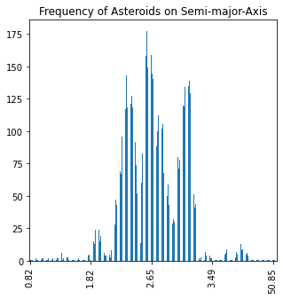

```python
asteroiddata2['smi-mjr_axis'] = asteroiddata2['smi-mjr_axis'].round(2)
smaplot = asteroiddata2['smi-mjr_axis'].value_counts().sort_index().plot.bar(figsize = (5, 5), title = 'Frequency of Asteroids on Semi-major-Axis')
#grabbing the frequency of asteroids on semi-major axis, and then sorting the index, which is where the semi-major axis lies, and finally plotting the result.
smaplot.xaxis.set_major_locator(plt.MaxNLocator(5)) #Evenly disperse a set number of ticks across the x axis, as to not fill the x axis with over 10,000 tick lables
```

Awesome. If we look at the graph above, we can see how the frequency of asteroids spike within certain ranges of semi-major axes, but divit doown between these spikes. These little gaps in frequencies are called the Kirkwood Gaps, and they exist because asteroids that may have previously been at or around those semi-major axis were associated with a certain period that caused them to be in orbital resonance with Jupiter. This means that those asteroids's periods were a simple fraction of the orbital period of Jupiter, which caused them to be either stable in that semi-major axis or nudged away from that axis.

### Visualization of Small Object Classes of Asteroids

We'll now scatterplot a graph that shows semi-major axis vs eccentricity and see if we can determine certain classes of these asteroids through the trends that show on the graph.

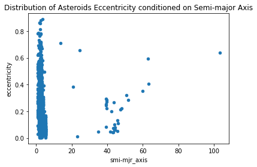

```python
aveplot = asteroiddata2.plot.scatter(x = 'smi-mjr_axis', y = 'eccentricity', title = 'Distribution of Asteroids Eccentricity conditioned on Semi-major Axis')
```

### Observing Possible Trends of Diameter of Asteroids conditioned on Discovery

For this graph, we will use our dataframe that contains the asteroids with recorded diameters. There is a common misconception by people getting into astronomy that the order of names for the asteroids are determined by size. This is not true! The order of names are determined by their date of discovery. However, many large asteroids are the first few on the graph because their size made it more likely for astronomers to discover earlier in history. Lets see if this relationship between size and order of discover pertains in later discovered asteroids!

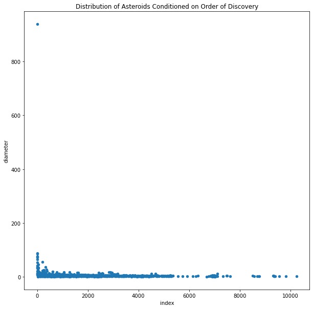

```python
asteroids_with_diameters2 = asteroids_with_diameters.reset_index() #We make our index a column so we can use that as the order of discovery in our x-axis
asteroids_with_diameters2.plot.scatter(x = 'index', y ='diameter', title = 'Distribution of Asteroids Conditioned on Order of Discovery',figsize =(10,10))
```

Ceres (The top left dot on the plot) seems to be an outlier in this data. Lets take take it out for better visualization of the graph and more accurate analysis.

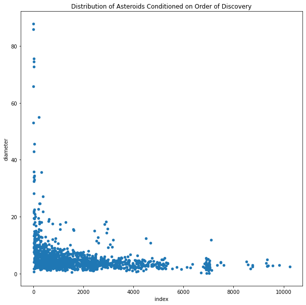

```python
newdiameterdata = asteroids_with_diameters[1:]
newdiameterdata = newdiameterdata.reset_index()
diameterplot = newdiameterdata.plot.scatter(x = 'index', y ='diameter', title = 'Distribution of Asteroids Conditioned on Order of Discovery',figsize =(10,10))
```

Well there does seem to be a trend that the diameter of the asteroids get smaller as more are discovered, with the distribution skewed to the right. but it seems to be more of an exponential decrease than a linear one. Lets try and fit a line in there.

## Linear and Polynomial Regression of Diameter of Asteroids Conditioned on Discovery Order

Though the trend does seem exponential, I believe our best fit would be a linear regression model, because the larger asteroids in the beginning of the graph are not the bulk of the scatter plot. We'll see if this line can fit onto the plot so that we could possibly predict the diameters of future asteroids.

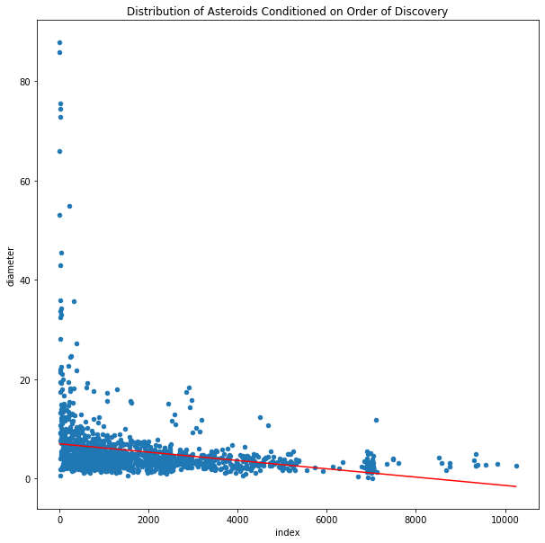

```python
diameterplot = newdiameterdata.plot.scatter(x = 'index', y ='diameter', title = 'Distribution of Asteroids Conditioned on Order of Discovery',figsize =(10,10))
lm = linear_model.LinearRegression()
ind = [[x] for x in newdiameterdata['index'].to_numpy()]
dep = newdiameterdata['diameter'].to_numpy()
lm.fit(ind, dep) #our lienar fit
diameterplot.plot(ind, lm.predict(ind), color = 'red') #plotting the line on the graph
```

It seems that our line somewhat fits with where the points are cocentrated, but past that, it goes under the actual values, proving it to be not even close at predicting future diameter values of asteroids. Lets try a polynomial fit

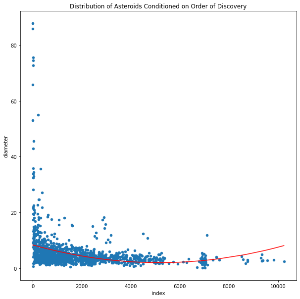

```python
diameterplot = newdiameterdata.plot.scatter(x = 'index', y ='diameter', title = 'Distribution of Asteroids Conditioned on Order of Discovery',figsize =(10,10))

c = np.polyfit(newdiameterdata['index'].to_numpy(), newdiameterdata['diameter'].to_numpy(), 2) # our index being x and out diameter being y
#c being the resulting coefficients
polynomial = np.poly1d(c)
diameterplot.plot(newdiameterdata['index'].to_numpy(), polynomial(newdiameterdata['index'].to_numpy()), "r-")
```

A little closer. However, the curve increases exponentially past the observed values of our plot. We'll try three degrees

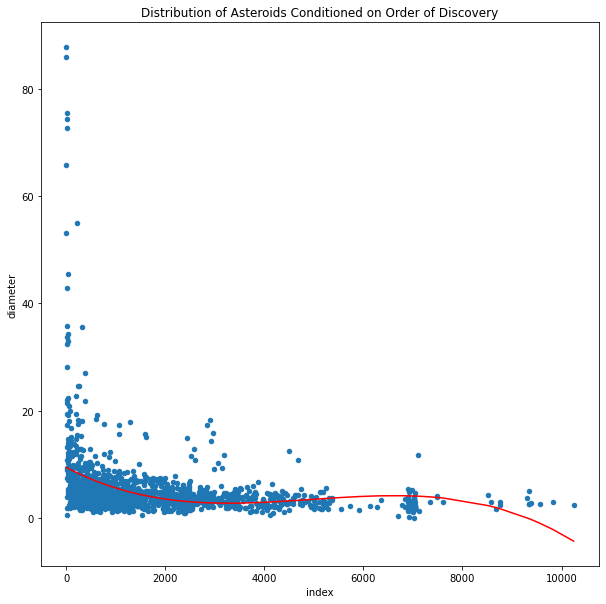

```python
diameterplot = newdiameterdata.plot.scatter(x = 'index', y ='diameter', title = 'Distribution of Asteroids Conditioned on Order of Discovery',figsize =(10,10))
c = np.polyfit(newdiameterdata['index'].to_numpy(), newdiameterdata['diameter'].to_numpy(), 3)
polynomial = np.poly1d(c)
diameterplot.plot(newdiameterdata['index'].to_numpy(), polynomial(newdiameterdata['index'].to_numpy()), "r-")
```

Also not quite. Predicting the future asteroid diameters might be a little more complex than I have imagined. Could a logarithmic regression fit?

## Review and Conclusions

In our tutorial, we were able to observe the datascience process. We collected our asteroid data from reliable sources and created a dataframe out of it. We then tidied up our data to make it easier to read and understand for the rest of our process. We did some visual demonstrations and analysis of certain scientific trends and asteroid properties, such as Kirkwood Gaps and asteroid classes, and finally our attempt at predicting future asteroid diameters. Though we were able to observe a trend of asteroid diameters over discovery order, we were not able to fit a good line or curve onto the plot. However, we were able to further explore this diameter and discovery relation.